# FAIR_bioinfo

Thomas Denecker & Claire Toffano-Nioche

[figure not shown]

Session 3

22/02/2019

## Session 3

Jouer avec les outils d'analyse

### Le projet

Analyse d'expression différentielle de gènes à partir de données RNAseq

## Programme session 3

- Présentation des outils du workflow (FastQC, Bowtie2, Samtools, HTseq-Count)
- Installation de FastQC à la main
- Présentation de conda
- Script pour l'installation de FastQC avec conda
- Amélioration du script d'installation : ajout des autres outils (travail à la maison)
- Amélioration du script d'analyse : workflow d'analyse à faire en boucle pour chaque échantillon (à faire tourner à la maison)

## Les données

Etude du métabolisme du fer chez *O. tauri*

[figure not shown]

### Origine des données

Organisme : *Ostreococcus tauri*

Type de données : RNAseq *single end*

Publication : [10.1186/s12864-016-2666-6](https://dx.doi.org/10.1186%2Fs12864-016-2666-6)

### Plan d'expérience

Répliques biologiques : 3

Conditions expérimentales différentes : 16

Etude de la différence +Fe / -Fe à 9h en lumière condition 1

[figure not shown]

### Plan d'expérience

Répliques biologiques : 3

Conditions expérimentales différentes : 16

Etude de la différence +Fe / -Fe à 9h en lumière condition 2

[figure not shown]

### Où sont les données?

**47 fichiers d'expériences**

[figure not shown]

## Le workflow

Présentation du workflow d'analyse

[figure not shown]

**Le choix des outils utilisés et des paramètres associés dépendent de la technologie de séquençage, de l'organisme étudié et de la question scientifique posée**

- **Technologie de séquençage : illumina, single-end**
- **Organisme : algue *O. tauri* => introns, de taille ~140 bp**
- **Question : analyse différentielle d'expression de gènes**

### Worflow d'analyse

Reads (fastq)

Génome de référence

Annotations du génome

FASTQC

Bowtie2

SAMtools

IGV

DEseq2

HTSeq

### Worflow d'analyse

Reads (fastq)

Génome de référence

Annotations du génome

FASTQC

Bowtie2

SAMtools

IGV

DEseq2

HTSeq

## Analyse qualité, FastQC

Reads (fastq)

FASTQC

```
@SRR3099585.1 HWI-ST365:427:H8K2HADXX:1:1101:1497:2215/1
CTCCCTTGACATCTCGATGTCCTTGGTGAGCTCGTCAACCGCGTCCGCACGATACATTTGGTATGTCTTGAATACCTTCGGGAATCGTTGACGATCTGGA
+
@@@DADDD8:CFH9E3:?AC?BF>AC<+C+<E?:8C?FEE0?D0@:'--;A?B;>>3(6;@B>5;5B@@A@:3>A#########################
@SRR3099585.2 HWI-ST365:427:H8K2HADXX:1:1101:1653:2087/1
GTCGACGAATATAAAGTTATTGGGAGAGACGCTGAAGGTCGCGTTGGAGATGGACTCAATTGCGCTTCGCGTTCGCCTCGTGGGTGTTCGCCCGGCTCAC
+
@CBFFFFFHHGHHJJJHHJJJJJJJJJIJJJJJJIJJJGHJJJJJJHHHHHFFFFFEEEEEEDDDDDDDDDDDDDDDDDDDDDDBDDDDDDDDDDDDDDD
@SRR3099585.3 HWI-ST365:427:H8K2HADXX:1:1101:1554:2142/1
CGACTCAATAACCTTGTCTTCGATCGGCGGCACGGAGCCAGTGATATCGCATTCGCCGGGGAACCACTCGAGCTCAGTCATCCGAGAGCGCAAGGGCGCT
...
```

**Objectif** : Réalisation d'un contrôle qualité des *reads* :

- histogramme de qualité selon la position des bases

- la taille des reads

- beaucoup d'autres critères

Rapport (html)

## Analyse qualité, FastQC

[figure not shown]

Rapport html : à regarder avec un navigateur

**Nécessite une inspection manuelle**

**Pas de décision automatisée**

**Bonne**

**qualité**

**Qualité**

**moyenne**

**Mauvaise qualité**

## Analyse qualité, FastQC

[figure not shown]

**Mauvaise qualité ?**

Le plus souvent, il faut agir pour modifier les reads. Par exemple :

- supprimer les 20 dernières bases (trimmer)

- Retirer les adaptateurs (cutadapt)

**Que faire si la qualité n'est pas bonne ?**

## Analyse qualité, FastQC

6 fichiers de reads

6 FastQC

[figure not shown]

*Un des fastQC du projet*

6x

### Worflow d'analyse

Reads (fastq)

Génome de référence

Annotations du génome

FASTQC

Bowtie2

SAMtools

IGV

DEseq2

HTSeq

## Mapping, bowtie2

Reads (fastq)

Bowtie2

Génome de référence (fasta)

```
@SRR3099585.1 HWI-ST365:427:H8K2HADXX:1:1101:1497:2215/1
CTCCCTTGACATCTCGATGTCCTTGGTGAGCTCGTCAACCGCGTCCGCACGATACATTTGGTATGTCTTGAATACCTTCGGGAATCGTTGACGATCTGGA
+
@@@DADDD8:CFH9E3:?AC?BF>AC<+C+<E?:8C?FEE0?D0@:'--;A?B;>>3(6;@B>5;5B@@A@:3>A#########################
@SRR3099585.2 HWI-ST365:427:H8K2HADXX:1:1101:1653:2087/1
GTCGACGAATATAAAGTTATTGGGAGAGACGCTGAAGGTCGCGTTGGAGATGGACTCAATTGCGCTTCGCGTTCGCCTCGTGGGTGTTCGCCCGGCTCAC
+
@CBFFFFFHHGHHJJJHHJJJJJJJJJIJJJJJJIJJJGHJJJJJJHHHHHFFFFFEEEEEEDDDDDDDDDDDDDDDDDDDDDDBDDDDDDDDDDDDDDD
@SRR3099585.3 HWI-ST365:427:H8K2HADXX:1:1101:1554:2142/1
CGACTCAATAACCTTGTCTTCGATCGGCGGCACGGAGCCAGTGATATCGCATTCGCCGGGGAACCACTCGAGCTCAGTCATCCGAGAGCGCAAGGGCGCT
+
@@<DDDD;DHF8?<CHG+AE<CBH??)@D:@8A';B'5?7..).;>@C1??@3>5;8'5&05<(8<899889@@CCA@C#####################
@SRR3099585.4 HWI-ST365:427:H8K2HADXX:1:1101:1598:2160/1
CCAGCCTCTCGCGACGACGGCGGCGTGGGAGGTCATGCCGCCGCGCGCGGTGAGGATGCCCTCAGCGGCGTCCATGCCGCCGACATCTTCTGGAGACGTC
+
@@@DDDBDFF@D@AGHIFI>>FA9?D;?@A@B?<C>8@A966<BB9978B8B<?BCDCDCDCBACC58;909>BEDD@5@@B55<@DCDEDDDDBAB@<<
@SRR3099585.5 HWI-ST365:427:H8K2HADXX:1:1101:1955:2129/1
CCCGGCGTGAAAATCAGTCGTCCAAACAGTGGCGCGCCTCTGTAGCGCCCGTGCCTCGAGGTCATACACGCTCGTAGAGTTGAAATCACTCGTCTTTGTC
+
?@?ADDDDHHDFH>FH?2CF?CDGIIIH@BBBD6DFAHGIICFH?><BDCC9;?AA5;=@B7?@CDCCC?BBB;>B<?C:>AACCCCAC@@@<?<@C>4>
@SRR3099585.6 HWI-ST365:427:H8K2HADXX:1:1101:2198:2175/1
CCTCGAGCACCAAAATCATCCCGCTGTCCTGGAGCAATTGCAACTTCTCCGCAGTCTCCGCCGGTGATCTCGGCGGGGGGGCGGCGGTGCGCACGAGCTC
+
```

**Objectif** : localisation des reads sur le génome de référence

```
>NC_014426.2 Ostreococcus tauri WGS project CAID00000000 data, contig chromosome 01, whole genome shotgun sequence
ccctaaaccctaaaccctaaaccctaaaccctaaaccctaaaccctaaaccctaaaccctaaaccctaaaccctaaaccc
taaaccctaaaccctaaaccctaaaccctaaaccctaaaccctaaaccctaaaccctaaacgaTGCATTACTACTCACAC
GAACGAGTGAATGAAACACACGAAACACAACTATCTGCATGGGAATGCGATGCTTTCTGACGATATGTTACACGATTCGA
GTGTCATCGTCTTTTCAATGACGCTTGCGCTCCGAAaatgctcgcgcgctgagcTACGGACCCTGTTTTGTATTCGACAT
CATCATCCGTTTTTATCGGCGCCGAGCCCTCAAAAacagccgcgcgcgctgtgaTGCTCGGAGAGATATTTTCACCCTTC
GGCAAAGACACTGGGCTCTCGCGTTTGACGAGTTCGGGCTCTCGCATTGCCGCTGTCGCTCCATCTATTTTCACCCTGGT
CGGCTGCGACGGTTTTACGATCGTTACCGCTTGCGGTCTCTCCACGTCGGCTAAATCATccaagtcgtcgtcgatatCGC
TTTCCTCCTCGACCGAGCGATTCCGCCGCGCCACGGCGGCTGCCCACGCATCGTTTGTTTCAACTTCATACGGCGTAACA
GCAGTGACCAACGGTATCGCCGCTGATGGCGGCGTTATAACCTTCTGTGCCGCAGCACGGACGACCGGTGCGCACGCGAC
AGGCTCTTTCACaaccggcggcggcatTTGCGACGCTTTCTTAATCGCGTCCGACTCCCTCGCTTTGAAAACGTTTGACG
CGACTGAAATTGCAGTCGGAACTTCAACATTTGCCTCGTGGTGCGATGAGACATTCGACTGCGAACGAGCCGACGCAGAA
GAGAAGAAATCCGTCTTCGGCGTTAATGACACATCCGCCCCTTTAGCTGATTCTGATTCTGTCACGATTGGTTCAACCTC
TAGGGGAAGATTTGGCACATTAGTCAGCTCTGGATTGTGCGTCGCGTTTTCGTTCAATACGCGCTCGGCTTCGTCAGCGC
TCACACCCGTtagacgctcgagctcggcgagctgTTTGCGAAGCGCCTCCATCTCATCCGCTGTTCCAGCCTCGCCACTC
GAGTCGTTTGTGGACGGAAGCGCATTTCGTTTCAcattcgcgacgccgccctcgAGTACATTTCCTACAAATCGCACTTC
GCGTTCAAAATTTTCTTCGTCGAGGAACTCCTCCTCAAACACTGAAGCTCGCGCgggtcgaggcgctcgctcggTCTCGA
```

```
SRR3099585.16   16      NC_014443.2     249781  42      100M    *       0       0       TCCCGCGTCTGGAAAGCCGCGCGATGAGATCCTCGAGGAGGTTGGAGCGATGCTCGATAAGTTTGACGACGTCATGAGTGCGGAAGAGAACGACGATGAG    >B>@DDDDDEDDCBDDBD@<BCCACCDDDDDDDDDDDEC>C@CBFHA:GHIGGEAGHEIIIGIGIIIHDJJIJJJJGIIJHHGHEIHHHHGHFFFFFBBB AS:i:0  XN:i:0  XM:i:0  XO:i:0  XG:i:0  NM:i:0  MD:Z:100        YT:Z:UU
SRR3099585.17   0       NC_014427.2     503521  42      100M    *       0       0       AGCATACGCTGCTGGAGCCGGAAGTTGAGCTGCGGCGTCATCACGCCACTTTCCATCGTACTCTTATACTCCTTCTGAAGCTCTTCGATCTGTTTTTGCA    @;?DDDDDH?1<AA<C;>FE1?EHHIDGFGFB@F<?'-@=?C=?BD?>ACCCCCDCABB<9?CA>ACCCCC>CCCA(4::CCC>CCB@>@@@::>9?0>@ AS:i:0  XN:i:0  XM:i:0  XO:i:0  XG:i:0  NM:i:0  MD:Z:100        YT:Z:UU
SRR3099585.18   16      NC_014431.2     518181  42      100M    *       0       0       TCCATCCGTTTTCGGAGGTAAATTCATAGGCGAAGTTATGCCAGCCCGCGATACGGAGCGATGTACACTAGCCCGCTCCGCGTTGAATGTACCAGTAGCG    CB@<8?BC>CBBB?@A@DCCDDAACC>9>5<@DCCC@CCBB<BB<8BBCCCBCCABEDFE@HE=??CED>HFFIGF:GCGHIBGGIGBHF<HFFDFFC@@ AS:i:0  XN:i:0  XM:i:0  XO:i:0  XG:i:0  NM:i:0  MD:Z:100        YT:Z:UU
SRR3099585.19   0       NC_014427.2     236213  42      100M    *       0       0       GCCCATTTCTTCGCGCTTCTTCTTACCGCGCAAGTGAGTCCCAAGCTGCAACAGACAAATAAAACAAGCGTCGTCAGTCGAATGTATTTTGGATCATTCC    BCCFFFFFHHHHHJJJJJJJJJJJJJJJIJJJJJHIJJJJJJHIIJJJJJHHHHHFFFFFEEEEEDDDDDBDDDDDDDDDDDDDDEEEEEDDDDDDDEEE AS:i:0  XN:i:0  XM:i:0  XO:i:0  XG:i:0  NM:i:0  MD:Z:100        YT:Z:UU
```

localisation (sam)

## Mapping, bowtie2

```
SRR3099585.16   16      NC_014443.2     249781  42      100M    *       0       0       TCCCGCGTCTGGAAAGCCGCGCGATGAGATCCTCGAGGAGGTTGGAGCGATGCTCGATAAGTTTGACGACGTCATGAGTGCGGAAGAGAACGACGATGAG    >B>@DDDDDEDDCBDDBD@<BCCACCDDDDDDDDDDDEC>C@CBFHA:GHIGGEAGHEIIIGIGIIIHDJJIJJJJGIIJHHGHEIHHHHGHFFFFFBBB AS:i:0  XN:i:0  XM:i:0  XO:i:0  XG:i:0  NM:i:0  MD:Z:100        YT:Z:UU
SRR3099585.17   0       NC_014427.2     503521  42      100M    *       0       0       AGCATACGCTGCTGGAGCCGGAAGTTGAGCTGCGGCGTCATCACGCCACTTTCCATCGTACTCTTATACTCCTTCTGAAGCTCTTCGATCTGTTTTTGCA    @;?DDDDDH?1<AA<C;>FE1?EHHIDGFGFB@F<?'-@=?C=?BD?>ACCCCCDCABB<9?CA>ACCCCC>CCCA(4::CCC>CCB@>@@@::>9?0>@ AS:i:0  XN:i:0  XM:i:0  XO:i:0  XG:i:0  NM:i:0  MD:Z:100        YT:Z:UU
SRR3099585.18   16      NC_014431.2     518181  42      100M    *       0       0       TCCATCCGTTTTCGGAGGTAAATTCATAGGCGAAGTTATGCCAGCCCGCGATACGGAGCGATGTACACTAGCCCGCTCCGCGTTGAATGTACCAGTAGCG    CB@<8?BC>CBBB?@A@DCCDDAACC>9>5<@DCCC@CCBB<BB<8BBCCCBCCABEDFE@HE=??CED>HFFIGF:GCGHIBGGIGBHF<HFFDFFC@@ AS:i:0  XN:i:0  XM:i:0  XO:i:0  XG:i:0  NM:i:0  MD:Z:100        YT:Z:UU
SRR3099585.19   0       NC_014427.2     236213  42      100M    *       0       0       GCCCATTTCTTCGCGCTTCTTCTTACCGCGCAAGTGAGTCCCAAGCTGCAACAGACAAATAAAACAAGCGTCGTCAGTCGAATGTATTTTGGATCATTCC    BCCFFFFFHHHHHJJJJJJJJJJJJJJJIJJJJJHIJJJJJJHIIJJJJJHHHHHFFFFFEEEEEDDDDDBDDDDDDDDDDDDDDEEEEEDDDDDDDEEE AS:i:0  XN:i:0  XM:i:0  XO:i:0  XG:i:0  NM:i:0  MD:Z:100        YT:Z:UU
```

Format texte avec des colonnes :

- **Nom du read** (colonne 1 : SRR3099585.18 )
- **Position de chaque read sur le génome** (colonne 4 : 518181)
- **CIGAR** (*Concise Idiosyncratic Gapped Alignment Report* ) (colonne 6 : 100M)
- ...

6 fichiers de reads 6 sam

Fichier de sortie : **.sam** (Sequence Alignment Map)

6x

## Colonnes du fichier SAM

| Col | Field | Type | Brief Description |
| --- | --- | --- | --- |
| 1 | QNAME | String | Query template NAME |
| 2 | FLAG | Int | bitwise FLAG |
| 3 | RNAME | String | References sequence NAME |
| 4 | POS | Int | 1- based leftmost mapping POSition |
| 5 | MAPQ | Int | MAPping Quality |
| 6 | CIGAR | String | CIGAR String |
| 7 | RNEXT | String | Ref. name of the mate/next read |
| 8 | PNEXT | Int | Position of the mate/next read |
| 9 | TLEN | Int | observed Template LENgth |
| 10 | SEQ | String | segment SEQuence |
| 11 | QUAL | String | ASCII of Phred-scaled base QUALity+33 |

## CIGAR

*Compact Idiosyncratic Gapped Alignment Report*

Chaîne de caractères qui indique de façon synthétique l'alignement du read sur le génome de référence.

| M | Match/Mismatch | Exact match or mismatch of x positions |
| --- | --- | --- |
| N | Alignment gap | Next x positions on ref don’t match |
| D | Deletion | Next x positions on ref don’t match |
| I | Insertion | Next x positions on query don’t match |

```
0123456789
AAGTCTAGAA (ref)
  GTGTAG   (query)
```

```
0123456789
AAGTC  TAGAA (ref)
  GTCGATAG   (query)
```

CIGAR : 3M2I3M

### Worflow d'analyse

Reads (fastq)

Génome de référence

Annotations du génome

FASTQC

Bowtie2

SAMtools

IGV

DEseq2

HTSeq

## Traitements des mappings, SAMtools

Bowtie2

SAMtools

1- Conversion SAM en BAM

(+/- sélection de reads)

2- Tri et index

SAM

BAM (binary align map)

BAI (BAM index)

6 fois

[figure not shown]

## Traitements des mappings, SAMtools

**1- Conversion SAM en BAM**

```
SRR3099585.1    0       NC_014429.2     517050  42      100M    *       0       0       CTCCCTTGACATCTCGATGTCCTTGGTGAGCTCGTCAACCGCGTCCGCACGATACATTTGGTATGTCTTGAATACCTTCGGGAATCGTTGACGATCTGGA    @@@DADDD8:CFH9E3:?AC?BF>AC<+C+<E?:8C?FEE0?D0@:'--;A?B;>>3(6;@B>5;5B@@A@:3>A######################### AS:i:-6 XN:i:0  XM:i:3  XO:i:0  XG:i:0  NM:i:3  MD:Z:76G5T5G11  YT:Z:UU
SRR3099585.2    0       NC_014431.2     29281   42      100M    *       0       0       GTCGACGAATATAAAGTTATTGGGAGAGACGCTGAAGGTCGCGTTGGAGATGGACTCAATTGCGCTTCGCGTTCGCCTCGTGGGTGTTCGCCCGGCTCAC    @CBFFFFFHHGHHJJJHHJJJJJJJJJIJJJJJJIJJJGHJJJJJJHHHHHFFFFFEEEEEEDDDDDDDDDDDDDDDDDDDDDDBDDDDDDDDDDDDDDD AS:i:-5 XN:i:0  XM:i:1  XO:i:0  XG:i:0  NM:i:1  MD:Z:46A53      YT:Z:UU
SRR3099585.3    16      NC_014440.2     89634   40      100M    *       0       0       AGCGCCCTTGCGCTCTCGGATGACTGAGCTCGAGTGGTTCCCCGGCGAATGCGATATCACTGGCTCCGTGCCGCCGATCGAAGACAAGGTTATTGAGTCG    #####################C@ACC@@988998<8(<50&5'8;5>3@??1C@>;.)..7?5'B;'A8@:D@)??HBC<EA+GHC<?8FHD;DDDD<@@ AS:i:-14        XN:i:0  XM:i:5  XO:i:0  XG:i:0  NM:i:5  MD:Z:36C3T17T4G35T0     YT:Z:UU
SRR3099585.4    16      NC_014427.2     869647  42      100M    *       0       0       GACGTCTCCAGAAGATGTCGGCGGCATGGACGCCGCTGAGGGCATCCTCACCGCGCGCGGCGGCATGACCTCCCACGCCGCCGTCGTCGCGAGAGGCTGG    <<@BABDDDDEDCD@<55B@@5@DDEB>909;85CCABCDCDCDCB?<B8B8799BB<669A@8>C<?B@A@?;D?9AF>>IFIHGA@D@FFDBDDD@@@ AS:i:0  XN:i:0  XM:i:0  XO:i:0  XG:i:0  NM:i:0  MD:Z:100        YT:Z:UU
SRR3099585.5    0       NC_014444.2     80679   42      100M    *       0       0       CCCGGCGTGAAAATCAGTCGTCCAAACAGTGGCGCGCCTCTGTAGCGCCCGTGCCTCGAGGTCATACACGCTCGTAGAGTTGAAATCACTCGTCTTTGTC    ?@?ADDDDHHDFH>FH?2CF?CDGIIIH@BBBD6DFAHGIICFH?><BDCC9;?AA5;=@B7?@CDCCC?BBB;>B<?C:>AACCCCAC@@@<?<@C>4> AS:i:0  XN:i:0  XM:i:0  XO:i:0  XG:i:0  NM:i:0  MD:Z:100        YT:Z:UU
SRR3099585.6    16      NC_014435.2     136707  42      100M    *       0       0       GAGCTCGTGCGCACCGCCGCCCCCCCGCCGAGATCACCGGCGGAGACTGCGGAGAAGTTGCAATTGCTCCAGGACAGCGGGATGATTTTGGTGCTCGAGG    ######################D@DDDDDDDDC?B@DDFFHGHDIIIHGJJHJJJJIJJIGIGJIGCCIIGIIHJJIGHJIIJJIJIHHFFHFDDDD?== AS:i:-8 XN:i:0  XM:i:4  XO:i:0  XG:i:0  NM:i:4  MD:Z:13A1A0G4T78        YT:Z:UU
SRR3099585.7    4       *       0       0       *       *       0       0       CATCGCTCGTCTTCGCCCGGTCGCTCATCCTCTAGATCGGAAGAGCACACGTCTGAACTCCAGTCACATTCCTTTATCTCGTATGCCGTCTTCTGCTTGA    ???BDFDDD:DFAHEH>H<CGBFGHGIFGBGFGCCHCHD;@CGDHHEECAD??AA:@>@AC55555>3;AC@CCCCC@A588<C9>:55<ABCCCAAC>A YT:Z:UU
SRR3099585.8    16      NC_014432.2     405245  42      100M    *       0       0       TAACGCCAATTAGCACGAATTCGTTTAGTCTCGTTTAGTCGCGGGAGATGAGTTTACGCTAAGAGCGTATGGTTCTGCAGTAAACACGTGTTGTACCACC    DB>BAACDCDCB@BDDDDB?BBCDDDDD?6?DDDCDDDFEEGGIJIJIIIIIJIHEGJJJIHGGGFJIJJIIHGIIIGEIIHBJIJJHHFGGEDDFFC@@ AS:i:0  XN:i:0  XM:i:0  XO:i:0  XG:i:0  NM:i:0  MD:Z:100        YT:Z:UU
SRR3099585.9    16      NC_014439.2     176178  42      100M    *       0       0       CCTCACGAAGAAGGCTGAGGAAGGCAAGCTTGACCCGTGCATCGGCCGCGTGAACGAAATCATTCGTGTCACGCAAATTCTCGGACGCCGTACCAAGAAC    DDDDDDDDDDDDDDDDDDDDDDDDDDDDDDDDBDDDDDDDDDDDDDDFFFFHHHHJJJJJJJJJJJJJJJJJJJJJJJJJJJJJJJJHHHHHFFFFFCCB AS:i:0  XN:i:0  XM:i:0  XO:i:0  XG:i:0  NM:i:0  MD:Z:100        YT:Z:UU
SRR3099585.10   16      NC_014443.2     282577  42      100M    *       0       0       GGGATGGCGCGCGAATCGATCGATGCGACGATCGAAACGATCGCGCGGGCGATGACGACGACAGCGGCGAGCTCGTCGTCGACGTCGTTTTTAGGACGCG    DDDDDDDDDDDDDDDDDDDDDDDDDDDDDDEDDDDDDDDDDDDDDDDDDCDDDDDDDDDDDDDDFHHJJIHFJIJJJJJJIIJJJIJHHHHHFFFDD@BB AS:i:0  XN:i:0  XM:i:0  XO:i:0  XG:i:0  NM:i:0  MD:Z:100        YT:Z:UU
SRR3099585.11   16      NC_014438.2     170775  42      100M    *       0       0       ACGTGGTGTTGCATCGGTTGCTCAGAGAGTGCGAGGGCGGAGAGTTCAAGCACGAGTTTTTCAGGTTTTTGGAGTTTTTATCTCGGAAAACGCACGCGCT    DDDB?DDDDDDDDDDDDCCACDDDDDD@DDDBDBDDBDEEDEEEFFFFFHHHHIHIJJJJJJIJJJJJJJIJIJJJIHIHIIJJIHIHGHFHFDFFFC@B AS:i:-5 XN:i:0  XM:i:1  XO:i:0  XG:i:0  NM:i:1  MD:Z:99C0       YT:Z:UU
SRR3099585.12   4       *       0       0       *       *       0       0       CAAGCCGAGGCACACCGTGCTCACCGGAGCTCGGCAGAACTGCATCGCGTCGTAAATCCCCATCCCACCCGTCACAGATCGGAAGAGCACACGTCTGAAC    @@@FFDD@8C?CFACE?E??FGDC>6087?=<;8F6;;E@??CDC>?AA>338?<?55::<?CCA84+89-)28?CCC43<@<(5<83:<<A928<?CA> YT:Z:UU
SRR3099585.13   0       NC_014428.2     737914  42      100M    *       0       0       GGAGGCAGCTTGGGAGCTTGTGTTAACCTTGGACTTCAATCCGAGCTTGACATCACCATTGGTGTAGCCAAGGTTAACCGTGGCGTCTTGGCTCGGCACA    B@BFFFFFHHHGGIHGIIIGIIGHIJJJJJIIJIGIIHHIGIGIIIIGIJIIIIIGHHIGIFHHEHEDDFCFDACCCECBBDDDBBDDDDDDDDDDBBBC AS:i:0  XN:i:0  XM:i:0  XO:i:0  XG:i:0  NM:i:0  MD:Z:100        YT:Z:UU
SRR3099585.14   0       NC_014436.2     271388  42      100M    *       0       0       GCCGAGTTGGATCGCTCGCCCTCCTTTGGGACGTCCATGACGTCGTCGAAGATTTCGAGCGCGTTCAAGAACGCCTGGTCCATGTTGAAGTACTTGTACG    @@CFFFFFGHHHHIIIJJJJJJJJIJJIHJIIJJJJIJJJIJJJJHHHFFDDEEEDDD=@BDDBBDDEDDDD>BDDDDADDDEDEEDDDDCCDEEDDDED AS:i:0  XN:i:0  XM:i:0  XO:i:0  XG:i:0  NM:i:0  MD:Z:100        YT:Z:UU
SRR3099585.15   16      NC_014429.2     713270  40      100M    *       0       0       CCGATCTGAGAGATCGACTTCACGCAGTTCGACACTCGAAACTTCGACGCGCCGTGCGCTGCGGCGACGGTAGAGGCGCTCCCAGAGCGAGACGCAAGAG    DDDCDDDCEDDBB?BCADBDBBDDDDDBA;:+8@DBDEDDBBB8B@7:B?:DDDBDFFFFJIIJJJJIJHIGGGIGHGGGDIHHEHFHHHDHFFFFFB@@ AS:i:-15        XN:i:0  XM:i:3  XO:i:0  XG:i:0  NM:i:3  MD:Z:0G2T2G93   YT:Z:UU
SRR3099585.16   16      NC_014443.2     249781  42      100M    *       0       0       TCCCGCGTCTGGAAAGCCGCGCGATGAGATCCTCGAGGAGGTTGGAGCGATGCTCGATAAGTTTGACGACGTCATGAGTGCGGAAGAGAACGACGATGAG    >B>@DDDDDEDDCBDDBD@<BCCACCDDDDDDDDDDDEC>C@CBFHA:GHIGGEAGHEIIIGIGIIIHDJJIJJJJGIIJHHGHEIHHHHGHFFFFFBBB AS:i:0  XN:i:0  XM:i:0  XO:i:0  XG:i:0  NM:i:0  MD:Z:100        YT:Z:UU
SRR3099585.17   0       NC_014427.2     503521  42      100M    *       0       0       AGCATACGCTGCTGGAGCCGGAAGTTGAGCTGCGGCGTCATCACGCCACTTTCCATCGTACTCTTATACTCCTTCTGAAGCTCTTCGATCTGTTTTTGCA    @;?DDDDDH?1<AA<C;>FE1?EHHIDGFGFB@F<?'-@=?C=?BD?>ACCCCCDCABB<9?CA>ACCCCC>CCCA(4::CCC>CCB@>@@@::>9?0>@ AS:i:0  XN:i:0  XM:i:0  XO:i:0  XG:i:0  NM:i:0  MD:Z:100        YT:Z:UU
SRR3099585.18   16      NC_014431.2     518181  42      100M    *       0       0       TCCATCCGTTTTCGGAGGTAAATTCATAGGCGAAGTTATGCCAGCCCGCGATACGGAGCGATGTACACTAGCCCGCTCCGCGTTGAATGTACCAGTAGCG    CB@<8?BC>CBBB?@A@DCCDDAACC>9>5<@DCCC@CCBB<BB<8BBCCCBCCABEDFE@HE=??CED>HFFIGF:GCGHIBGGIGBHF<HFFDFFC@@ AS:i:0  XN:i:0  XM:i:0  XO:i:0  XG:i:0  NM:i:0  MD:Z:100        YT:Z:UU
SRR3099585.19   0       NC_014427.2     236213  42      100M    *       0       0       GCCCATTTCTTCGCGCTTCTTCTTACCGCGCAAGTGAGTCCCAAGCTGCAACAGACAAATAAAACAAGCGTCGTCAGTCGAATGTATTTTGGATCATTCC    BCCFFFFFHHHHHJJJJJJJJJJJJJJJIJJJJJHIJJJJJJHIIJJJJJHHHHHFFFFFEEEEEDDDDDBDDDDDDDDDDDDDDEEEEEDDDDDDDEEE AS:i:0  XN:i:0  XM:i:0  XO:i:0  XG:i:0  NM:i:0  MD:Z:100        YT:Z:UU
SRR3099585.20   16      NC_014427.2     941467  42      100M    *       0       0       CGCGGCGGCGCTCGCGGCCAAGTCGGCGCTGGCGATCACGATCCCGTCCCAAGCGTCGAGCGGTGGTCTCGGCCGCGGCTCTGGCATCGCTTTCTCTTCC    DDDDBDDDDDBB@B<CCDDBDDBDDDDB>BDDDDCDA<BDDBDDDDDDDDDDDDDBDBCDFFFHHHIJJIJIJIIJJJJIJJJIIJIHHHHHFFFFFCCC AS:i:0  XN:i:0  XM:i:0  XO:i:0  XG:i:0  NM:i:0  MD:Z:100        YT:Z:UU
```

[output not shown]

[output not shown]

**SAM**

**BAM**

254 Mo

Binaire

(optimal pour l’ordinateur)

1 404 Mo

Lisible

(optimal pour l'Homme)

## Traitements des mappings, SAMtools

**1- +/- sélection**

Tous les *reads* ne sont pas conservés :

- Ceux qui ne s'alignent pas

- Ceux qui s'alignent à plusieurs endroits (régions répétées)

**2- Tri et index**

Indexation pour optimiser la recherche

**Conclusion**

Plus léger donc plus rapide à parcourir (pour l'ordinateur !)

[output not shown]

**BAI**

[output not shown]

[output not shown]

**BAM**

### Worflow d'analyse

Reads (fastq)

Génome de référence

Annotations du génome

FASTQC

Bowtie2

SAMtools

IGV

DEseq2

HTSeq

### Visualisation

**Génome de référence**

Fichier fasta

**Annotations du génome**

Fichier gff

IGV

**Mapping des reads**

Fichier bam

### Fichier GFF

Fichier composé de 9 colonnes, indiquant les positions génomiques de début et de fin d’éléments génomiques d’intérêts.

| 1 | seqname | name of the chromosome or scaffold; chromosome names can be given with or without the 'chr' prefix. |
| --- | --- | --- |
| 2 | source | name of the program that generated this feature, or the data source |
| 3 | feature | feature type name |
| 4 | start | Start position of the feature, with sequence numbering starting at 1 |
| 5 | end | End position of the feature, with sequence numbering starting at 1 |
| 6 | score | A floating point value |
| 7 | strand | One of ".", "+" or "-". "+" when the feature stands on the same strand than the support sequence ("-" for reverse strand) |
| 8 | frame | One of '0', '1' or '2'. '0' indicates that the first base of the feature is the first base of a codon, '1' that the second base is the first base of a codon, and so on |
| 9 | attribute | A semicolon-separated list of tag-value pairs, providing additional information about each feature |

### Fichier GFF

Le fichier pour l'étude, O.tauri_annotation.gff contient les gènes

```
##gff-version 3
#!gff-spec-version 1.21
#!processor NCBI annotwriter
#!genome-build version 140606
#!genome-build-accession NCBI_Assembly:GCF_000214015.3
#!annotation-source INSDC submitter
##sequence-region NC_014426.2 1 1096037
##species https://www.ncbi.nlm.nih.gov/Taxonomy/Browser/wwwtax.cgi?id=70448
NC_014426.2     RefSeq  gene    244     1932    .       -       .       ID=ostta01g00010
NC_014426.2     RefSeq  gene    2077    4029    .       +       .       ID=ostta01g00020
NC_014426.2     RefSeq  gene    4157    5299    .       +       .       ID=ostta01g00030
NC_014426.2     RefSeq  gene    5392    7041    .       -       .       ID=ostta01g00040
NC_014426.2     RefSeq  gene    7386    9605    .       -       .       ID=ostta01g00050
NC_014426.2     RefSeq  gene    9780    10412   .       -       .       ID=ostta01g00060
NC_014426.2     RefSeq  gene    11358   12455   .       +       .       ID=ostta01g00070
NC_014426.2     RefSeq  gene    12585   12848   .       -       .       ID=ostta01g00080
NC_014426.2     RefSeq  gene    13009   15890   .       +       .       ID=ostta01g00090
NC_014426.2     RefSeq  gene    16094   20050   .       +       .       ID=ostta01g00100
NC_014426.2     RefSeq  gene    20110   20694   .       -       .       ID=ostta01g00110
NC_014426.2     RefSeq  gene    21003   22493   .       +       .       ID=ostta01g00120
```

### Integrative Genomics Viewer

Visualisation des reads alignés sur le génome

ostta18g0198

[figure not shown]

**+ FE**

**- FE**

Différence importante du nombre de reads alignés

gène (gff)

génome (fasta)

mapping (bam)

### Worflow d'analyse

Reads (fastq)

Génome de référence

Annotations du génome

FASTQC

Bowtie2

SAMtools

IGV

DEseq2

HTSeq

## Comptage, HTseq

```
ostta01g00010   305
ostta01g00020   156
ostta01g00030   23
ostta01g00040   725
ostta01g00050   500
ostta01g00060   226
ostta01g00070   137
ostta01g00080   22
ostta01g00090   931
ostta01g00100   558
ostta01g00110   5
ostta01g00120   249
ostta01g00130   270
ostta01g00140   916
ostta01g00150   0
ostta01g00160   171
ostta01g00170   35
ostta01g00180   7
ostta01g00190   93
ostta01g00200   50
ostta01g00210   90
```

**Annotations du génome**

Fichier GFF

HTSeq

**Mapping des reads**

Fichier BAM

L’activité transcriptionnelle des gènes est supposée proportionnelle au nombre de séquences observées

Comptage du nombre de *reads* par gène

6 fois

### Worflow d'analyse

Reads (fastq)

Génome de référence

Annotations du génome

FASTQC

Bowtie2

SAMtools

IGV

DEseq2

HTSeq

1 fois

### Analyse différentielle, DESeq2

Création d'une table de comptage unique

[figure not shown]

### Analyse différentielle, DESeq2

Obtention d'un *logFC* et d'une *pValue* ajustée permettent de sélectionner des gènes à étudier

Le + il y a de répliques dans chaque condition, le + le test statistique est puissant

[figure not shown]

Analyse différentielle de l'expression des gènes basée sur un modèle statistique

# Bilan du workflow

Reads (fastq)

Génome de référence

Annotations du génome

FASTQC

Bowtie2

SAMtools

IGV

DEseq2

HTSeq

[figure not shown]

```
@SRR3099585.1 HWI-ST365:427:H8K2HADXX:1:1101:1497:2215/1
CTCCCTTGACATCTCGATGTCCTTGGTGAGCTCGTCAACCGCGTCCGCACGATACATTTGGTATGTCTTGAATACCTTCGGGAATCGTTGACGATCTGGA
+
@@@DADDD8:CFH9E3:?AC?BF>AC<+C+<E?:8C?FEE0?D0@:'--;A?B;>>3(6;@B>5;5B@@A@:3>A#########################
@SRR3099585.2 HWI-ST365:427:H8K2HADXX:1:1101:1653:2087/1
GTCGACGAATATAAAGTTATTGGGAGAGACGCTGAAGGTCGCGTTGGAGATGGACTCAATTGCGCTTCGCGTTCGCCTCGTGGGTGTTCGCCCGGCTCAC
+
@CBFFFFFHHGHHJJJHHJJJJJJJJJIJJJJJJIJJJGHJJJJJJHHHHHFFFFFEEEEEEDDDDDDDDDDDDDDDDDDDDDDBDDDDDDDDDDDDDDD
@SRR3099585.3 HWI-ST365:427:H8K2HADXX:1:1101:1554:2142/1
CGACTCAATAACCTTGTCTTCGATCGGCGGCACGGAGCCAGTGATATCGCATTCGCCGGGGAACCACTCGAGCTCAGTCATCCGAGAGCGCAAGGGCGCT
...
```

```
>NC_014426.2 Ostreococcus tauri WGS project CAID00000000 data, contig chromosome 01, whole genome shotgun sequence
ccctaaaccctaaaccctaaaccctaaaccctaaaccctaaaccctaaaccctaaaccctaaaccctaaaccctaaaccc
taaaccctaaaccctaaaccctaaaccctaaaccctaaaccctaaaccctaaaccctaaacgaTGCATTACTACTCACAC
GAACGAGTGAATGAAACACACGAAACACAACTATCTGCATGGGAATGCGATGCTTTCTGACGATATGTTACACGATTCGA
GTGTCATCGTCTTTTCAATGACGCTTGCGCTCCGAAaatgctcgcgcgctgagcTACGGACCCTGTTTTGTATTCGACAT
CATCATCCGTTTTTATCGGCGCCGAGCCCTCAAAAacagccgcgcgcgctgtgaTGCTCGGAGAGATATTTTCACCCTTC
GGCAAAGACACTGGGCTCTCGCGTTTGACGAGTTCGGGCTCTCGCATTGCCGCTGTCGCTCCATCTATTTTCACCCTGGT
CGGCTGCGACGGTTTTACGATCGTTACCGCTTGCGGTCTCTCCACGTCGGCTAAATCATccaagtcgtcgtcgatatCGC
TTTCCTCCTCGACCGAGCGATTCCGCCGCGCCACGGCGGCTGCCCACGCATCGTTTGTTTCAACTTCATACGGCGTAACA
GCAGTGACCAACGGTATCGCCGCTGATGGCGGCGTTATAACCTTCTGTGCCGCAGCACGGACGACCGGTGCGCACGCGAC
AGGCTCTTTCACaaccggcggcggcatTTGCGACGCTTTCTTAATCGCGTCCGACTCCCTCGCTTTGAAAACGTTTGACG
CGACTGAAATTGCAGTCGGAACTTCAACATTTGCCTCGTGGTGCGATGAGACATTCGACTGCGAACGAGCCGACGCAGAA
GAGAAGAAATCCGTCTTCGGCGTTAATGACACATCCGCCCCTTTAGCTGATTCTGATTCTGTCACGATTGGTTCAACCTC
TAGGGGAAGATTTGGCACATTAGTCAGCTCTGGATTGTGCGTCGCGTTTTCGTTCAATACGCGCTCGGCTTCGTCAGCGC
TCACACCCGTtagacgctcgagctcggcgagctgTTTGCGAAGCGCCTCCATCTCATCCGCTGTTCCAGCCTCGCCACTC
GAGTCGTTTGTGGACGGAAGCGCATTTCGTTTCAcattcgcgacgccgccctcgAGTACATTTCCTACAAATCGCACTTC
GCGTTCAAAATTTTCTTCGTCGAGGAACTCCTCCTCAAACACTGAAGCTCGCGCgggtcgaggcgctcgctcggTCTCGA
CTCGACGCTCAGCGATCGGCGCTGATGTTGGTGATGGCACAGGAGCCGAACACGTTGTTTGATCCTGCTCATACACCGGC
ACGCTAGCCGGCGCTAAACGCGTCGcatacgcgcgcgaaccttGTTCGTATGCCATTCTCTGTCCACCGAGAGTCTGCTG
cccgccacgcgcgtgcggcgcgtATCCTCCTCTTTCGTCGTACGT...
```

```
##gff-version 3
#!gff-spec-version 1.21
#!processor NCBI annotwriter
#!genome-build version 140606
#!genome-build-accession NCBI_Assembly:GCF_000214015.3
#!annotation-source INSDC submitter
##sequence-region NC_014426.2 1 1096037
##species https://www.ncbi.nlm.nih.gov/Taxonomy/Browser/wwwtax.cgi?id=70448
NC_014426.2    RefSeq    gene	244	1932	.	-	.	ID=ostta01g00010
NC_014426.2    RefSeq    gene	2077	4029	.	+	.	ID=ostta01g00020
NC_014426.2    RefSeq    gene	4157	5299	.	+	.	ID=ostta01g00030
...
```

fastq

fasta

gff

```
SRR3099585.1  0  NC_014429.2  517050  42  100M  *  0  0  CTCCCTTGACATCTCGATGTCCTTGGTGAGCTCGTCAACCGCGTCCGCACGATACATTTGGTATGTCTTGAATACCTTCGGGAATCGTTGACGATCTGGA  @@@DADDD8:CFH9E3:?AC?BF>AC<+C+<E?:8C?FEE0?D0@:'--;A?B;>>3(6;@B>5;5B@@A@:3>A#########################  AS:i:-6  XN:i:0  XM:i:3  XO:i:0  XG:i:0  NM:i:3  MD:Z:76G5T5G11  YT:Z:UU
SRR3099585.2  0  NC_014431.2   29281  42  100M  *  0  0  GTCGACGAATATAAAGTTATTGGGAGAGACGCTGAAGGTCGCGTTGGAGATGGACTCAATTGCGCTTCGCGTTCGCCTCGTGGGTGTTCGCCCGGCTCAC  @CBFFFFFHHGHHJJJHHJJJJJJJJJIJJJJJJIJJJGHJJJJJJHHHHHFFFFFEEEEEEDDDDDDDDDDDDDDDDDDDDDDBDDDDDDDDDDDDDDD  AS:i:-5  XN:i:0  XM:i:1  XO:i:0  XG:i:0  NM:i:1  MD:Z:46A53  YT:Z:UU
SRR3099585.1    0       NC_014429.2     517050  42      100M    *       0       0       CTCCCTTGACATCTCGATGTCCTTGGTGAGCTCGTCAACCGCGTCCGCACGATACATTTGGTATGTCTTGAATACCTTCGGGAATCGTTGACGATCTGGA    @@@DADDD8:CFH9E3:?AC?BF>AC<+C+<E?:8C?FEE0?D0@:'--;A?B;>>3(6;@B>5;5B@@A@:3>A######################### AS:i:-6 XN:i:0  XM:i:3  XO:i:0  XG:i:0  NM:i:3  MD:Z:76G5T5G11  YT:Z:UU
SRR3099585.2    0       NC_014431.2     29281   42      100M    *       0       0       GTCGACGAATATAAAGTTATTGGGAGAGACGCTGAAGGTCGCGTTGGAGATGGACTCAATTGCGCTTCGCGTTCGCCTCGTGGGTGTTCGCCCGGCTCAC    @CBFFFFFHHGHHJJJHHJJJJJJJJJIJJJJJJIJJJGHJJJJJJHHHHHFFFFFEEEEEEDDDDDDDDDDDDDDDDDDDDDDBDDDDDDDDDDDDDDD AS:i:-5 XN:i:0  XM:i:1  XO:i:0  XG:i:0  NM:i:1  MD:Z:46A53      YT:Z:UU
SRR3099585.3    16      NC_014440.2     89634   40      100M    *       0       0       AGCGCCCTTGCGCTCTCGGATGACTGAGCTCGAGTGGTTCCCCGGCGAATGCGATATCACTGGCTCCGTGCCGCCGATCGAAGACAAGGTTATTGAGTCG    #####################C@ACC@@988998<8(<50&5'8;5>3@??1C@>;.)..7?5'B;'A8@:D@)??HBC<EA+GHC<?8FHD;DDDD<@@ AS:i:-14        XN:i:0  XM:i:5  XO:i:0  XG:i:0  NM:i:5  MD:Z:36C3T17T4G35T0     YT:Z:UU
SRR3099585.4    16      NC_014427.2     869647  42      100M    *       0       0       GACGTCTCCAGAAGATGTCGGCGGCATGGACGCCGCTGAGGGCATCCTCACCGCGCGCGGCGGCATGACCTCCCACGCCGCCGTCGTCGCGAGAGGCTGG    <<@BABDDDDEDCD@<55B@@5@DDEB>909;85CCABCDCDCDCB?<B8B8799BB<669A@8>C<?B@A@?;D?9AF>>IFIHGA@D@FFDBDDD@@@ AS:i:0  XN:i:0  XM:i:0  XO:i:0  XG:i:0  NM:i:0  MD:Z:100        YT:Z:UU
SRR3099585.5    0       NC_014444.2     80679   42      100M    *       0       0       CCCGGCGTGAAAATCAGTCGTCCAAACAGTGGCGCGCCTCTGTAGCGCCCGTGCCTCGAGGTCATACACGCTCGTAGAGTTGAAATCACTCGTCTTTGTC    ?@?ADDDDHHDFH>FH?2CF?CDGIIIH@BBBD6DFAHGIICFH?><BDCC9;?AA5;=@B7?@CDCCC?BBB;>B<?C:>AACCCCAC@@@<?<@C>4> AS:i:0  XN:i:0  XM:i:0  XO:i:0  XG:i:0  NM:i:0  MD:Z:100        YT:Z:UU
SRR3099585.6    16      NC_014435.2     136707  42      100M    *       0       0       GAGCTCGTGCGCACCGCCGCCCCCCCGCCGAGATCACCGGCGGAGACTGCGGAGAAGTTGCAATTGCTCCAGGACAGCGGGATGATTTTGGTGCTCGAGG    ######################D@DDDDDDDDC?B@DDFFHGHDIIIHGJJHJJJJIJJIGIGJIGCCIIGIIHJJIGHJIIJJIJIHHFFHFDDDD?== AS:i:-8 XN:i:0  XM:i:4  XO:i:0  XG:i:0  NM:i:4  MD:Z:13A1A0G4T78        YT:Z:UU
```

```
ostta01g00010   305
ostta01g00020   156
ostta01g00030   23
ostta01g00040   725
ostta01g00050   500
ostta01g00060   226
ostta01g00070   137
ostta01g00080   22
ostta01g00090   931
...
```

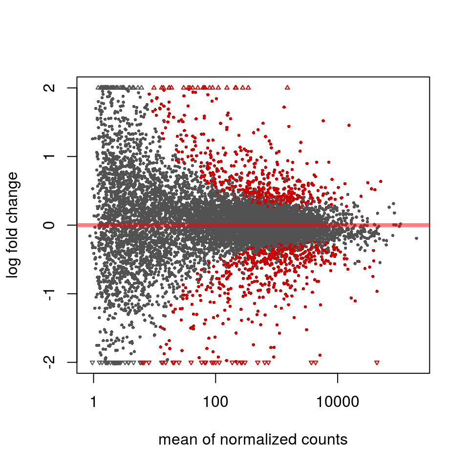

tri

6

6 fois

1

1

6 fois

6 fois

6 fois

1 fois

6 fois

6 fois

## Etape 1

Installation du premier outil, FastQC

### Navigateur : FastQC

https://www.bioinformatics.babraham.ac.uk/projects/download.html

[figure not shown]

Décompresser le fichier téléchargé

et lire la documentation

### Ouvrir un terminal

[figure not shown]

### Installation de FastQC

Aller avec un cd jusqu'au fichier décompressé

puis

```bash
tdenecker@DESKTOP-B8ON598:fastqc_v0.11.8/FastQC$ ./fastqc
Can't exec "java": No such file or directory at ./fastqc line 283.
```

### Installation de java

[figure not shown]

### Problématiques

- Installation de java (pas toujours simple surtout pour linux)
- Utilisation de fastqc
- Mise à jour de fastqc

Installation plus simple?

## Etape 2

Installation automatique,

conda

[figure not shown]

Gestionnaire de paquets et d'environnements *open source*

- Installation des paquets

- Exécution des paquets

- Mise à jour des paquets

Multi-plateforme : Windows, macOS et Linux

Pas de problèmes de compilation, de dépendances,..., Conda se charge de tout !

Il existe des canaux de diffusion dans Conda

Bioconda est un canal de diffusion de logiciels, utilisable par le gestionnaire de paquets conda et proposant de nombreux logiciels utilisés en bioinformatique.

Tous les outils linux utilisés dans ce projet sont sur bioconda

[figure not shown]

### Installation de Fastqc par Conda

```bash
# Téléchargement
wget --quiet https://repo.anaconda.com/miniconda/Miniconda3-latest-Linux-x86_64.sh

# Installation
bash Miniconda3-latest-Linux-x86_64.sh -b

# Suppression du fichier téléchargé
rm Miniconda3-latest-Linux-x86_64.sh
```

**Téléchargement de miniconda**

Version légère de conda

**Ajout du chemin dans le path**

Pour utiliser la commande conda directement

```bash
export PATH=~/miniconda3/bin:$PATH
```

**Mise à jour de conda**

### Installation de Fastqc par Conda

```bash
## Update
conda update conda
conda update --all
```

**Ajout des canaux de diffusion**

```bash
## Add channels
conda config --add channels conda-forge
conda config --add channels bioconda
```

**Installation de fastqc**

```bash
conda install -y fastqc
```

L'installation de java a été réalisée par conda (dépendance)

# Et voilà !

# Et voilà !

[figure not shown]

**Pas si simple !**

**Beaucoup de commandes !**

[figure not shown]

**L'autre méthode est plus facile**

### Mais c'est vrai pour fastQC

Mais maintenant pour les autres

```bash
conda install -y bowtie2 htseq samtools
```

### Mais c'est vrai pour fastQC

Mais maintenant pour les autres

```bash
conda install -y bowtie2 htseq samtools
```

et c'est tout!

[figure not shown]

### Script complet d'installation

```bash
# Installation - conda
wget --quiet https://repo.anaconda.com/miniconda/Miniconda3-latest-Linux-x86_64.sh
bash Miniconda3-latest-Linux-x86_64.sh -b
rm Miniconda3-latest-Linux-x86_64.sh

## Add in path
export PATH=~/miniconda3/bin:$PATH

## Update
conda update conda
conda update --all

## Add chanel
conda config --add channels conda-forge
conda config --add channels bioconda

## Install fastqc, bowtie2, htseq and samtools
conda install -y fastqc bowtie2 htseq samtools
```

## Etape 3

Rappel : Automatisation du téléchargement

### Script en fin de session 2

```bash
##------------------------------------------------------------------------------
## FAIR script
## Author: T. Denecker & C. Toffano-Nioche
## Affiliation: I2BC
## Aim: A workflow to process RNA-Seq.
## Organism: O. tauri
## Date: Jan 2019
## Step :
## 1- Create tree structure
## 2- Download data from SRA
##------------------------------------------------------------------------------

echo "=============================================================="
echo "Creation of tree structure"
echo "=============================================================="

mkdir Project
mkdir Project/samples
mkdir Project/annotations
mkdir Project/bowtie2
mkdir Project/fastqc
mkdir Project/genome
mkdir Project/graphics
mkdir Project/htseq
mkdir Project/reference
mkdir Project/samtools

echo "=============================================================="
echo "Download data from SRA"
echo "=============================================================="

cd Project/samples

IFS=$'\n'       # make newlines the only separator
for j in $(tail -n +2 ../../conditions.txt)
do

    # Get important information from the line
    access=$( echo "${j}" | cut -f6 )
    id=$( echo "${j}" | cut -f1 )
    md5=$( echo "${j}" | cut -f7 )

    echo "--------------------------------------------------------------"
    echo ${id}
    echo "--------------------------------------------------------------"

    # Download file
    wget ${access} # wget method

    # Get md5 of downloaded file
    md5_local="$(md5sum ${id}.fastq.gz | cut -d' ' -f1)"
    echo ${md5_local}

    # Test md5
    if [ "${md5_local}" == "${md5}" ]
    then
        echo "Done"
    else
        echo "Nope"
        exit 1
    fi
done

cd ../..
exit 0
```

### Retour sur la boucle

[figure not shown]

Faire répéter à l'ordinateur la même chose mais avec des valeurs différentes

### Retour sur la boucle

Nous souhaitons faire la même action **pour** toutes les lignes du fichier "conditions.txt"

[figure not shown]

- 1ère col. pour la variable "id"

- 6ème colonne pour la variable "access"

- 7ème col. pour la variable "md5"

### Retour sur la boucle

```bash
for j in $(tail -n +2 ../../conditions.txt)
do
    [...]
done
```

En Unix pour lire ligne par ligne :

Le contenu de la ligne est stocké dans une variable nommée j

### Pour chaque ligne de conditions.txt

```bash
access=$( echo "${j}" | cut -f6 )
```

1- Récupérer l'adresse wget, l'identifiant et le md5 de la ligne j

Si nous décomposons la commande en français :

1. Accès du contenu de la ligne (variable) : ${j}
2. Affichage du contenu de la ligne sous forme de chaîne de caractères : echo "${j}"
3. Sur cette chaîne de caractères, nous allons appliquer une autre commande : |
4. Nous sélectionnons le contenu de la colonne 6 : cut -f6
5. Nous stockons le tout dans une nouvelle variable : =$( )

### Pour chaque ligne de conditions.txt

```bash
access=$( echo "${j}" | cut -f6 )
```

1- Récupérer l'adresse wget, l'identifiant et le md5 de la ligne j

Si nous décomposons la commande en français :

1. Accès du contenu de la ligne (variable) : ${j}
2. Affichage du contenu de la ligne sous forme de chaîne de caractères : echo "${j}"
3. Sur cette chaîne de caractères, nous allons appliquer une autre commande : |
4. Nous sélectionnons le contenu de la colonne 6 : cut -f6
5. Nous stockons le tout dans une nouvelle variable : =$( )

Principe réalisé 3 fois en changeant de colonne :

```bash
access=$( echo "${j}" | cut -f6 )
id=$( echo "${j}" | cut -f1 )
md5=$( echo "${j}" | cut -f7 )
```

### Pour chaque ligne de conditions.txt

2- Télécharger le fichier

```bash
wget ${access}
```

3- Calcul et affichage du md5 du fichier téléchargé

```bash
md5_local="$(md5sum ${id}.fastq.gz | cut -d' ' -f1)"
echo ${md5_local}
```

Rappel : **${**access**}** permet d'accéder au contenu de la variable "access"

A vous !

### Pour chaque ligne de conditions.txt

4- Tester si les 2 md5 (le local et l'espéré) sont identiques : l'original

```bash
if [ "${md5_local}" == "${md5}" ]
then
    echo "Done"
else
    echo "Nope"
    exit 1
fi
```

== test d'égalité != test d'inégalité

**En français**

Si le md5 présent dans le fichier conditions.txt est égal au md5 du fichier téléchargé

alors afficher "Done"

sinon afficher "Nope" et quitter avec une erreur 1

## Et nous recommençons pour chaque ligne de conditions.txt

### Téléchargement du génome et du fichier d'annotation

```bash
echo "=============================================================="
echo "Download annotations"
echo "=============================================================="

wget https://raw.githubusercontent.com/thomasdenecker/FAIR_Bioinfo/master/Data/O.tauri_annotation.gff -P Project/annotations

echo "=============================================================="
echo "Download genome"
echo "=============================================================="

wget https://raw.githubusercontent.com/thomasdenecker/FAIR_Bioinfo/master/Data/O.tauri_genome.fna -P Project/genome
```

Stockage dans les dossiers précédemment créés

### Architecture à la fin de la session 2

```
tdenecker@DESKTOP-B8ON598:~/Fair_project$ tree Project/
Project/
├── annotations
│   └── O.tauri_annotation.gff
├── bowtie2
├── fastqc
├── genome
│   └── O.tauri_genome.fna
├── graphics
├── htseq
├── reference
├── samples
│   ├── SRR3099585.fastq.gz
│   ├── SRR3099586.fastq.gz
│   ├── SRR3099587.fastq.gz
│   ├── SRR3105697.fastq.gz
│   ├── SRR3105698.fastq.gz
│   └── SRR3105699.fastq.gz
└── samtools
```

## Etape 4

Script du workflow d'analyse

### Avec un échantillon

```bash
# Nom du fichier sans le .fastq.gz
sample="SRR3099585"
# nom du fichier contenant le génome de référence
genome="./Project/genome/O.tauri_genome.fna"
# nom du fichier contenant les annotations
annotations="./Project/annotations/O.tauri_annotation.gff"

echo "=============================================================="
echo "Contrôle qualité - échantillon ${sample}"
echo "=============================================================="
fastqc Project/samples/${sample}.fastq.gz --outdir Project/fastqc/

echo "=============================================================="
echo "Indexation du génome de référence"
echo "=============================================================="
bowtie2-build ${genome} O_tauri

echo "=============================================================="
echo "Alignement des reads sur le génome de référence - échantillon ${sample}"
echo "=============================================================="
bowtie2 -x O_tauri -U Project/samples/${sample}.fastq.gz -S Project/bowtie2/bowtie-${sample}.sam 2> Project/bowtie2/bowtie-${sample}.out

echo "=============================================================="
echo "Conversion en binaire, tri et indexation des reads alignés - échantillon ${sample}"
echo "=============================================================="
samtools view -b Project/bowtie2/bowtie-${sample}.sam > Project/samtools/bowtie-${sample}.bam
samtools sort Project/samtools/bowtie-${sample}.bam -o Project/samtools/bowtie-${sample}.sorted.bam
samtools index Project/samtools/bowtie-${sample}.sorted.bam

echo "=============================================================="
echo "Comptage - échantillon ${sample}"
echo "=============================================================="
htseq-count --stranded=no --type='gene' --idattr='ID' --order=name --format=bam Project/samtools/bowtie-${sample}.sorted.bam ${annotations} > Project/htseq/count-${sample}.txt

echo "=============================================================="
echo "Nettoyage des fichiers inutiles - échantillon ${sample}"
echo "=============================================================="
rm -f Project/samtools/bowtie-${sample}.sam Project/bowtie2/bowtie-${sample}.bam
```

# Et maintenant ?

[figure not shown]

### **Pour** **plusieurs échantillons**

```bash
# Liste des fichiers fastq.gz à analyser
dirlist=$(find Project/samples/*.fastq.gz)
# nom du fichier contenant le génome de référence
genome="./Project/genome/O.tauri_genome.fna"
# nom du fichier contenant les annotations
annotations="./Project/annotations/O.tauri_annotation.gff"

for file in ${dirlist}
do
    # Name without path
    file_name="$(basename $file)"
    # Name without path and .gz
    nameFastq="${file_name%.*}"
    # Name without path, .gz and fastq
    sample="${nameFastq%.*}"

    echo "====================================================================="
    echo "Contrôle qualité - échantillon ${sample}"
    echo "====================================================================="
    fastqc Project/samples/${sample}.fastq.gz --outdir Project/fastqc/

    echo "====================================================================="
    echo "Indexation du génome de référence"
    echo "====================================================================="
    bowtie2-build ${genome} O_tauri

    echo "====================================================================="
    echo "Alignement des reads sur le génome de référence - échantillon ${sample}"
    echo "====================================================================="
    bowtie2 -x O_tauri -U Project/samples/${sample}.fastq.gz -S Project/bowtie2/bowtie-${sample}.sam 2> Project/bowtie2/bowtie-${sample}.out

    echo "====================================================================="
    echo "Conversion en binaire, tri et indexation des reads alignés - échantillon ${sample}"
    echo "====================================================================="
    samtools view -b Project/bowtie2/bowtie-${sample}.sam > Project/samtools/bowtie-${sample}.bam
    samtools sort Project/samtools/bowtie-${sample}.bam -o Project/samtools/bowtie-${sample}.sorted.bam
    samtools index Project/samtools/bowtie-${sample}.sorted.bam

    echo "====================================================================="
    echo "Comptage - échantillon ${sample}"
    echo "====================================================================="
    htseq-count --stranded=no --type='gene' --idattr='ID' --order=name --format=bam Project/samtools/bowtie-${sample}.sorted.bam ${annotations} > Project/htseq/count-${sample}.txt

    echo "=============================================================="
    echo "Nettoyage des fichiers inutiles - échantillon ${sample}"
    echo "=============================================================="
    rm -f Project/samtools/bowtie-${sample}.sam Project/bowtie2/bowtie-${sample}.bam

done
```

### **Différences pour le multiple**

```bash
# Liste des fichiers fastq.gz à analyser
dirlist=$(find Project/samples/*.fastq.gz)

[...]

for file in ${dirlist}
do
    # Name without path
    file_name="$(basename $file)"
    # Name without path and .gz
    nameFastq="${file_name%.*}"
    # Name without path, .gz and fastq
    sample="${nameFastq%.*}"
    [...]

done
```

1- Récupération de la liste des fichiers

2- Pour chaque fichier, préparation de la variable "sample" :

1- retrait du chemin d'accès

2- retrait des extensions

### **Et le reste?**

Il n'y a aucun changement car nous utilisons les mêmes variables

Intérêt :

- pas beaucoup de changements pour lancer sur tous les fichiers RNAseq

- Nous n'avons plus qu'à attendre la fin

### **Et le reste?**

Il n'y a aucun changement car nous utilisons les mêmes variables

Intérêt :

- pas beaucoup de changements pour lancer sur tous les fichiers RNAseq

- Nous n'avons plus qu'à attendre la fin... et c'est long

[figure not shown]

### **L'arborescence**

## **Attention**

Projet pèse 15 Go maintenant !

```bash
Project/
├── annotations
│   └── O.tauri_annotation.gff
├── bowtie2
│   ├── bowtie-.out
│   ├── bowtie-SRR3099585.out
│   ├── bowtie-SRR3099585.sam
│   ├── bowtie-SRR3099586.out
│   ├── ...
│   └── bowtie-SRR3105699.sam
├── fastqc
│   ├── SRR3099585_fastqc.html
│   ├── SRR3099585_fastqc.zip
│   ├── ...
│   └── SRR3105699_fastqc.zip
├── genome
│   └── O.tauri_genome.fna
├── graphics
├── htseq
│   ├── count-SRR3099585.txt
│   ├── count-SRR3099586.txt
│   ├── ...
│   └── count-SRR3105699.txt
├── reference
├── samples
│   ├── SRR3099585.fastq.gz
│   ├── SRR3099585_fastqc.html
│   ├── SRR3099585_fastqc.zip
│   ├── SRR3099586.fastq.gz
│   ├── ...
│   └── SRR3105699_fastqc.zip
└── samtools
    ├── bowtie-SRR3099585.bam
    ├── bowtie-SRR3099585.sorted.bam
    ├── bowtie-SRR3099585.sorted.bam.bai
    ├── bowtie-SRR3099586.bam
    ├── ...
    └── bowtie-SRR3105699.sorted.bam.bai

9 directories, 69 files
```

# Et maintenant ?

[figure not shown]

## Conclusion

### Bilan de la session

Création d'un script d'analyse complet et automatique :

- Lancement de l'ensemble des outils d'analyse

- Organisation des fichiers de sortie

**Savoir FAIRe**

- Utilisation de Conda

- Un script d'installation des outils

- Un script de worflow pour l'analyse

### Pour la prochaine fois

Reproduire la session 3 (si pas fait lors de la session) :

- Utiliser le script et avoir les 6 tables de comptage
- Un github à jour

[figure not shown]

**Bon courage !**

RDV sur Slack en cas de problème